# Estimadores de riqueza

## Background da análise

Uma vez que determinar o número total de espécies numa área é praticamente impossível, principalmente em regiões com alta riqueza de espécies, os estimadores são úteis para extrapolar a riqueza observada e tentar estimar a riqueza total através de uma amostra incompleta de uma comunidade biológica (Walther and Moore 2005). Neste capítulo serão considerados os estimadores não paramétricos que usam informações da frequencia de espécies raras na comunidade (Gotelli and Chao 2013). Isto porque tanto os testes paramétricos que tentam determinar os parâmetros de uma curva usando o formato da curva de acumulação de espécies (e.g. equação logística, Michaelis-Menten) quanto os testes que usam a frequencia do número de indivíduos para enquadrá-las em uma das distribuições de abundância das espécies (e.g. distribuições log-séries, log-normal) não funcionam muito bem com dados empíricos (Gotelli and Chao 2013). Para mais detalhes sobre os testes paramétricos veja (Magurran and McGill 2011) e Colwell & Coddington (1994).

#### Quatro características para um bom estimador de riqueza (Chazdon et al. 1998; Hortal, Borges, and Gaspar 2006):

> - Independência do tamanho da amostra (quantidade de esforço amostral realizado);
> - Insensibilidade a diferentes padrões de distribuições (diferentes equitabilidades);
> - Insensibilidade em relação à ordem das amostragens;
> - Insensibilidade à heterogeneidade entre as amostras usadas entre estudos.

## Estimadores baseados na abundância das espécies

### CHAO 1 - (Chao 1984, 1987):

Estimador simples do número absoluto de espécies em uma comunidade. É baseado no número de espécies raras dentro de uma amostra.

> $$Chao_{1} = S_{obs} + \left(\frac{n-1}{n}\right)\frac{F_1(F_1-1)}{2(F_2+1)}$$

onde:

- S<sub>obs</sub> = o número de espécies na comunidade,
- *n* = número de amostras,
- F<sub>1</sub> = número de espécies observadas com abundância de um indivíduo (espécies *singleton*),
- F<sub>2</sub> = número de espécies observadas com abundância de dois indivíduos (espécies *doubletons*).

O valor de Chao 1 é máximo quando todas as espécies menos uma são únicas (*singleton*). Neste caso, a riqueza estimada é aproximadamente o dobro da riqueza observada.

#### Exemplo prático - Chao 1

##### Explicação dos dados

Neste exemplo usaremos os dados de 17 espécies de anuros amostradas em 14 dias de coletas de campo em um habitat reprodutivo localizado na região noroeste do estado de São Paulo, Brasil.

**Pergunta:**

> Quantas espécies a mais poderiam ser amostradas caso aumentasse o esforço amostral?

**Predições**

> - O número de espécies estimadas é similar ao número de espécies observada;
> - O número de espécies estimadas é maior do que o número de espécies observada.

**Variáveis**

- Variáveis preditoras
  - matriz ou vetor com as abundâncias das espécies de anuros registradas em uma habitat reprodutivo

**Checklist**

- Verificar se a sua matriz está com as espécies nas colunas e as amostragens nas linhas
- Verificar se os dados são de abundância e não presença e ausência

### Análise

Calculo do estimador de riqueza - Chao 1

```r
library(vegan)
dados_coleta <- read.csv("anuros_poca.csv", header = T, row.names = 1, sep = ";")
est_chao1 <- estaccumR(dados_coleta, permutations = 100)
summary(est_chao1, display = "chao")
```

```
## $chao
##         N      Chao   2.5%    97.5%  Std.Dev
## Dia_9   1  6.680000  3.000 12.33333 2.618883
## Dia_13  2  9.069429  6.000 16.78750 2.750151
## Dia_11  3 10.930000  7.000 15.52500 2.336780
## Dia_6   4 12.114500  9.000 17.00000 2.474635
## Dia_1   5 13.172500 10.000 20.00000 2.657345
## Dia_2   6 13.865000 10.000 22.00000 2.989759
## Dia_12  7 14.835000 10.000 22.00000 2.965050
## Dia_10  8 15.578333 11.000 22.00000 2.828869
## Dia_14  9 16.283333 12.000 22.00000 2.783882
## Dia_5  10 16.970000 13.000 22.00000 2.675950
## Dia_3  11 17.555000 13.475 22.00000 2.464798
## Dia_4  12 18.190000 14.500 22.00000 2.231297
## Dia_8  13 19.255000 15.500 22.00000 1.742944
## Dia_7  14 20.000000 20.000 20.00000 0.000000
##
## attr(,"class")
## [1] "summary.poolaccum"
```

Visualizar os resultados com intervalo de confiança de 95%.

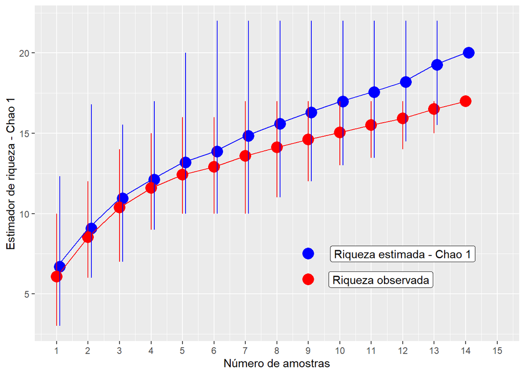

```r
library(ggplot2)
# preparando os dados para fazer o gráfico
resultados <- summary(est_chao1, display = c("S", "chao"))
res_chao <- cbind(resultados$chao[,1:4], resultados$S[,2:4])
res_chao <- as.data.frame(res_chao)
colnames(res_chao) <- c("Amostras", "Chao", "C_inferior", "C_superior", "Riqueza",
                        "R_inferior", "R_superior")

# comando para o gráfico
ggplot(res_chao, aes(y = Riqueza, x = Amostras)) +
  geom_point(aes(y = Chao, x = Amostras + 0.1), size = 5, color = "blue", alpha = 1) +
  geom_point(aes(y = Riqueza, x = Amostras), size = 5, color = "red", alpha = 1) +
  geom_line (aes(y = Chao, x = Amostras), color = "blue") +
  geom_line (aes(y = Riqueza, x = Amostras), color = "red") +
  geom_linerange(aes(ymin = C_inferior, ymax = C_superior, x = Amostras + 0.1),
 color = "blue") +
  geom_linerange(aes(ymin = R_inferior, ymax = R_superior, x = Amostras), color = "red") +
  ylab ("Estimador de riqueza - Chao 1") +
  xlab ("Número de amostras") +
  scale_x_continuous(limits = c(1,15), breaks=seq(1,15,1)) +
  geom_point(y= 7.5, x = 9, size = 5, color = "blue", alpha = 1) +
  geom_point(y= 5.9, x = 9, size = 5, color = "red", alpha = 1) +
  geom_label( y = 7.5, x = 12, label = "Riqueza estimada - Chao 1") +
  geom_label( y = 5.9, x = 11.3, label = "Riqueza observada")
```

#### Interpretação dos resultados

Com base no número de espécies raras (*singletons* e *doubletons*), o estimador Chao 1 indica a possibilidade de encontrarmos mais três espécies caso o esforço amostral fosse maior e não mostra tendência de estabilização da curva em uma assíntota.

### ACE - *Abundance-based Coverage Estimador* (Chao and Lee 1992; Chao et al. 2000):

Este método trabalha com a abundância das espécies raras (i.e. abundância baixa). Entretanto, diferente do estimador anterior, esse método permite ao pesquisador determinar os limites para os quais uma espécie seja considerada rara. Em geral, são consideradas raras espécies com abundância entre 1 e 10 indivíduos. A riqueza estimada pode variar conforme se aumente ou diminua o limiar de abundância, e infelizmente não existem critérios biológicos definidos para a escolha do melhor intervalo.

> $$ACE = S_{abund} + \frac{S_{rare}}{C_{ace}} + \frac{F_1}{C_{ace}}Y_{ace}^2$$

onde:

> $$Y_{ace}^2 = max \left[\frac{S_{rare}}{C_{ace}}\frac{\sum_{i=i}^{10}i(i-1)F1}{(N_{rare})({N_{rare} - 1)}}-1,0\right]$$

> $$C_{ace} = 1 - \frac{F1}{N_{rare}}$$

> $$N_{rare} = \sum_{i=1}^{10}iF_i$$

Não precisa fazer cara feia, é óbvio que iremos usar o programa para fazer esses cálculos.

#### Exemplo prático - ACE

##### Explicação dos dados

Usaremos os mesmos dados de 17 espécies de anuros amostradas em 14 dias de coletas de campo em um habitat reprodutivo localizado na região noroeste do estado de São Paulo, Brasil.

**Pergunta:**

> Quantas espécies a mais poderiam ser amostradas caso aumentasse o esforço amostral?

**Predições**

> - O número de espécies estimadas é similar ao número de espécies observada;
> - O número de espécies estimadas é maior do que o número de espécies observada.

**Variáveis**

- Variáveis preditoras
  - matriz ou vetor com as abundâncias das espécies de anuros registradas em uma habitat reprodutivo

**Checklist**

- Verificar se a sua matriz está com as espécies nas colunas e as amostragens nas linhas
- Verificar se os dados são de abundância e não presença e ausência

### Análise

Calculo do estimador de riqueza - ACE

```r
library(vegan)
dados_coleta <- read.csv("anuros_poca.csv", header = T, row.names = 1, sep = ";")
est_ace <- estaccumR(dados_coleta, permutations = 100)
summary(est_ace, display = "ace")
```

```
## $ace
##         N       ACE      2.5%    97.5%  Std.Dev
## Dia_11  1  6.796231  3.545190 13.71429 2.612105
## Dia_10  2  9.745017  6.000000 18.43698 3.221914
## Dia_1   3 11.395337  7.181094 18.32471 3.022225
## Dia_13  4 12.214767  8.636160 19.66252 2.954103
## Dia_2   5 13.265522  9.000000 20.47197 3.058393
## Dia_7   6 14.162206  9.660615 20.81389 2.817519
## Dia_9   7 15.339199 11.000000 22.34773 2.958972
## Dia_5   8 16.327463 11.475000 22.90598 3.217862
## Dia_12  9 18.053326 12.179636 24.93470 3.590351
## Dia_14 10 19.765452 13.827580 25.51766 3.703896
## Dia_4  11 21.355358 15.434363 25.72368 3.650544
## Dia_6  12 22.759826 16.904925 25.72368 3.014561
## Dia_3  13 24.089971 17.676471 25.72368 2.126530
## Dia_8  14 24.703704 24.703704 24.70370 0.000000
##
## attr(,"class")
## [1] "summary.poolaccum"
```

Visualizar os resultados com intervalo de confiança de 95%

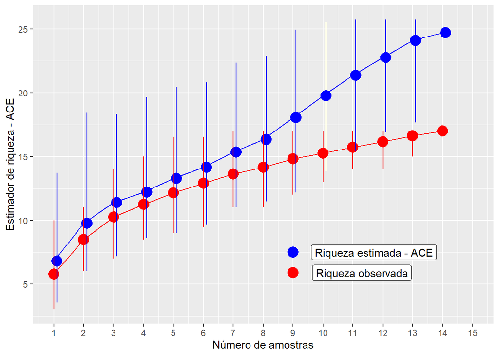

```r
library(ggplot2)
# preparando os dados para fazer o gráfico
resultados_ace <- summary(est_ace, display = c("S", "ace"))
res_ace <- cbind(resultados_ace$ace[,1:4], resultados_ace$S[,2:4])
res_ace <- as.data.frame(res_ace)
colnames(res_ace) <- c("Amostras", "ACE", "ACE_inferior", "ACE_superior", "Riqueza",
                        "R_inferior", "R_superior")

# comando para o gráfico
ggplot(res_ace, aes(y = Riqueza, x = Amostras)) +
  geom_point(aes(y = ACE, x = Amostras + 0.1), size = 5, color = "blue", alpha = 1) +
  geom_point(aes(y = Riqueza, x = Amostras), size = 5, color = "red", alpha = 1) +
  geom_line (aes(y = ACE, x = Amostras), color = "blue") +
  geom_line (aes(y = Riqueza, x = Amostras), color = "red") +
  geom_linerange(aes(ymin = ACE_inferior, ymax = ACE_superior, x = Amostras + 0.1),
 color = "blue") +
  geom_linerange(aes(ymin = R_inferior, ymax = R_superior, x = Amostras), color = "red") +
  ylab ("Estimador de riqueza - ACE") +
  xlab ("Número de amostras") +
  scale_x_continuous(limits = c(1,15), breaks=seq(1,15,1)) +
  geom_point(y= 7.5, x = 9, size = 5, color = "blue", alpha = 1) +
  geom_point(y= 5.9, x = 9, size = 5, color = "red", alpha = 1) +
  geom_label( y = 7.5, x = 11.7, label = "Riqueza estimada - ACE") +
  geom_label( y = 5.9, x = 11.3, label = "Riqueza observada")
```

#### Interpretação dos resultados

Com base no número de espécies raras (abundância menor que 10 indivíduos - *default*), o estimador ACE indica a possibilidade de encontrarmos mais sete espécies caso o esforço amostral fosse maior e não mostrou tendência de estabilição da curva em uma assíntota.

## Estimadores baseados na incidência das espécies

### CHAO 2 - (Chao 1987):

De acordo com Anne Chao, o estimador Chao 1 pode ser modificado para uso com dados de presença/ausência levando em conta a distribuição das espécies entre amostras. Neste caso é necessário somente conhecer o número de espécies encontradas em somente uma amostra e o número de espécies encontradas exatamente em duas amostras. Essa variação ficou denominada como Chao 2:

> $$Chao_{2} = S_{obs} + \left(\frac{m-1}{m}\right)\left(\frac{Q_1(Q_1-1)}{2(Q_2 + 1}\right)$$

onde:

- S<sub>obs</sub> = o número de espécies na comunidade,
- *m* = número de amostragens,
- Q<sub>1</sub> = número de espécies observadas em uma amostragem (espécies *uniques*),
- Q<sub>2</sub> = número de espécies observadas em duas amostragens (espécies *duplicates*).

O valor de Chao2 é máximo quando as espécies menos uma são únicas (*uniques*). Neste caso, a riqueza estimada é aproximadamente o dobro da riqueza observada. Colwell & Coddington (1994) encontraram que o valor de Chao 2 mostrou ser o estimador menos enviesado para amostras com tamanho pequeno.

#### Exemplo prático - Chao 2

##### Explicação dos dados

Usaremos os mesmos dados de 17 espécies de anuros amostradas em 14 dias de coletas de campo em um habitat reprodutivo localizado na região noroeste do estado de São Paulo, Brasil.

**Pergunta:**

> Quantas espécies a mais poderiam ser amostradas caso aumentasse o esforço amostral?

**Predições**

> - O número de espécies estimadas é similar ao número de espécies observada;
> - O número de espécies estimadas é maior do que o número de espécies observada.

**Variáveis**

- Variáveis preditoras
  - matriz ou vetor com a incidência das espécies de anuros registradas em uma habitat reprodutivo

**Checklist**

- Verificar se a sua matriz está com as espécies nas colunas e as amostragens nas linhas

### Análise

Calculo do estimador de riqueza - Chao 2

```r
library(vegan)
dados_coleta <- read.csv("anuros_poca.csv", header = T, row.names = 1, sep = ";")
est_chao2 <- poolaccum(dados_coleta, permutations = 100)
summary(est_chao2, display = "chao")
```

```
## $chao
##        N     Chao      2.5%    97.5%  Std.Dev
##  [1,]  3 14.13555  8.026389 27.46250 5.283627
##  [2,]  4 15.98690  8.237500 30.17812 6.181170
##  [3,]  5 16.72833  9.400000 28.92500 5.721394
##  [4,]  6 18.39424 11.171875 34.50625 6.410462
##  [5,]  7 19.61679 11.632143 35.57500 6.067136
##  [6,]  8 22.16990 11.773958 38.11562 6.950542
##  [7,]  9 23.18926 13.311111 40.41111 7.019151
##  [8,] 10 25.65550 13.900000 40.70375 7.368729
##  [9,] 11 27.85409 16.045455 42.45455 6.926050
## [10,] 12 29.57208 18.382292 39.45833 5.920494
## [11,] 13 31.16231 22.384615 39.61538 4.424138
## [12,] 14 33.71429 33.714286 33.71429 0.000000
##
## attr(,"class")
## [1] "summary.poolaccum"
```

Visualizar os resultados com intervalo de confiança de 95%

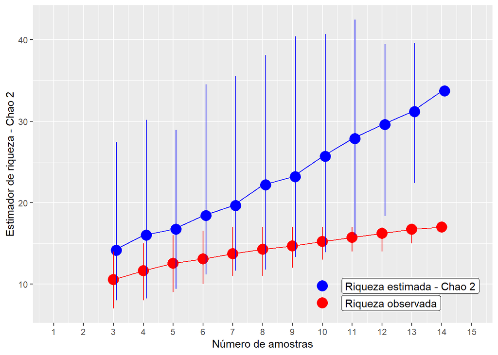

```r
library(ggplot2)
# preparando os dados para fazer o gráfico
resultados_chao2 <- summary(est_chao2, display = c("S", "chao"))
res_chao2 <- cbind(resultados_chao2$chao[,1:4], resultados_chao2$S[,2:4])
res_chao2 <- as.data.frame(res_chao2)
colnames(res_chao2) <- c("Amostras", "Chao2", "C_inferior", "C_superior", "Riqueza",
                        "R_inferior", "R_superior")

# comando para o gráfico
ggplot(res_chao2, aes(y = Riqueza, x = Amostras)) +
  geom_point(aes(y = Chao2, x = Amostras + 0.1), size = 5, color = "blue", alpha = 1) +
  geom_point(aes(y = Riqueza, x = Amostras), size = 5, color = "red", alpha = 1) +
  geom_line (aes(y = Chao2, x = Amostras), color = "blue") +
  geom_line (aes(y = Riqueza, x = Amostras), color = "red") +
  geom_linerange(aes(ymin = C_inferior, ymax = C_superior, x = Amostras + 0.1),
 color = "blue") +
  geom_linerange(aes(ymin = R_inferior, ymax = R_superior, x = Amostras), color = "red") +
  ylab ("Estimador de riqueza - Chao 2") +
  xlab ("Número de amostras") +
  scale_x_continuous(limits = c(1,15), breaks=seq(1,15,1)) +
  geom_point(y= 9.8, x = 10, size = 5, color = "blue", alpha = 1) +
  geom_point(y= 7.7, x = 10, size = 5, color = "red", alpha = 1) +
  geom_label( y = 9.8, x = 12.95, label = "Riqueza estimada - Chao 2") +
  geom_label( y = 7.7, x = 12.3, label = "Riqueza observada")
```

#### Interpretação dos resultados

Com base no número de espécies raras (*uniques* e *duplicates*), Chao 2 estimou a possibilidade de encontrarmos mais dezesseis espécies caso o esforço amostral fosse maior e não mostrou tendência de estabilização da curva em uma assíntota.

### JACKKNIFE 1 (Burnham and Overton 1978, 1979):

Este estimador baseia-se no número de espécies que ocorrem em somente uma amostra (Q1).

> $$S_{jack1} = S_{obs} + Q1\left(\frac{m - 1}{m}\right)$$

onde:

- S<sub>obs</sub> = o número de espécies na comunidade,
- Q<sub>1</sub> = número de espécies observadas em uma amostragem (espécies *uniques*),
- *m* = número de amostragens.

Palmer (1990) verificou que Jackknife 1 foi o estimador mais preciso e menos enviesado comparado a outros métodos de extrapolação.

#### Exemplo prático - Jackknife 1

##### Explicação dos dados

Usaremos os mesmos dados de 17 espécies de anuros amostradas em 14 dias de coletas de campo em um habitat reprodutivo localizado na região noroeste do estado de São Paulo, Brasil.

**Pergunta:**

> Quantas espécies a mais poderiam ser amostradas caso aumentasse o esforço amostral?

**Predições**

> - O número de espécies estimadas é similar ao número de espécies observada;
> - O número de espécies estimadas é maior do que o número de espécies observada.

**Variáveis**

- Variáveis preditoras
  - matriz ou vetor com as abundâncias das espécies de anuros registradas em uma habitat reprodutivo

**Checklist**

- Verificar se a sua matriz está com as espécies nas colunas e as amostragens nas linhas

### Análise

Calculo do estimador de riqueza - Jackknife 1

```r
library(vegan)
dados_coleta <- read.csv("anuros_poca.csv", header = T, row.names = 1, sep = ";")
est_jack1 <- poolaccum(dados_coleta, permutations = 100)
summary(est_jack1, display = "jack1")
```

```
## $jack1
##        N Jackknife 1     2.5%    97.5%  Std.Dev
##  [1,]  3    13.29333  6.00000 18.68333 3.068715
##  [2,]  4    14.12750  8.75000 20.25000 3.057218
##  [3,]  5    15.04400  9.69500 21.60000 3.082381
##  [4,]  6    15.99500 11.22917 21.00000 2.811458
##  [5,]  7    16.86714 12.71429 22.00000 2.727601
##  [6,]  8    17.79500 12.80937 23.12500 2.627645
##  [7,]  9    18.86222 13.31111 23.68889 2.742156
##  [8,] 10    19.63800 14.80000 24.20000 2.563882
##  [9,] 11    20.63545 15.25000 24.27273 2.330362
## [10,] 12    21.20917 16.75000 23.89792 2.025562
## [11,] 13    21.89769 18.69231 23.46154 1.417972
## [12,] 14    22.57143 22.57143 22.57143 0.000000
##
## attr(,"class")
## [1] "summary.poolaccum"
```

Visualizar os resultados com 95% intervalo de confiança

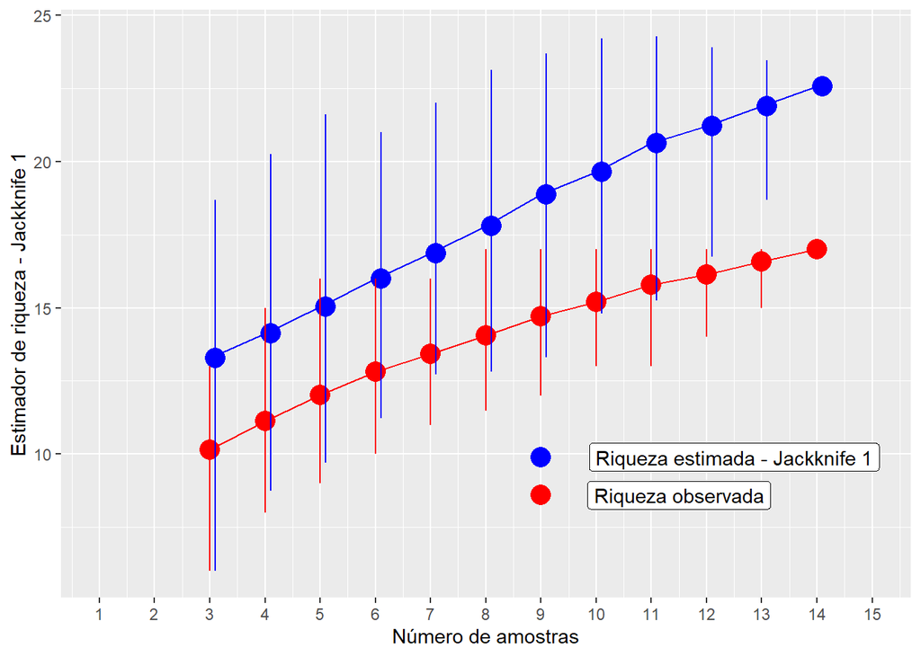

```r
library(ggplot2)
# preparando os dados para fazer o gráfico
resultados_jack1 <- summary(est_jack1, display = c("S", "jack1"))
res_jack1 <- cbind(resultados_jack1$jack1[,1:4], resultados_jack1$S[,2:4])
res_jack1 <- as.data.frame(res_jack1)
colnames(res_jack1) <- c("Amostras", "JACK1", "JACK1_inferior", "JACK1_superior", "Riqueza",
                        "R_inferior", "R_superior")

# comando para o gráfico
ggplot(res_jack1, aes(y = Riqueza, x = Amostras)) +
  geom_point(aes(y = JACK1, x = Amostras + 0.1), size = 5, color = "blue", alpha = 1) +
  geom_point(aes(y = Riqueza, x = Amostras), size = 5, color = "red", alpha = 1) +
  geom_line (aes(y = JACK1, x = Amostras), color = "blue") +
  geom_line (aes(y = Riqueza, x = Amostras), color = "red") +
  geom_linerange(aes(ymin = JACK1_inferior, ymax = JACK1_superior, x = Amostras + 0.1),
 color = "blue") +
  geom_linerange(aes(ymin = R_inferior, ymax = R_superior, x = Amostras), color = "red") +
  ylab ("Estimador de riqueza - Jackknife 1") +
  xlab ("Número de amostras") +
  scale_x_continuous(limits = c(1,15), breaks=seq(1,15,1)) +
  geom_point(y= 9.9, x = 9, size = 5, color = "blue", alpha = 1) +
  geom_point(y= 8.6, x = 9, size = 5, color = "red", alpha = 1) +
  geom_label( y = 9.9, x = 12.5, label = "Riqueza estimada - Jackknife 1") +
  geom_label( y = 8.6, x = 11.5, label = "Riqueza observada")
```

#### Interpretação dos resultados

Com base no número de espécies raras, o estimador Jackknife 1 calculou a possibilidade de encontrarmos mais seis espécies caso o esforço amostral fosse maior e não mostrou tendência de estabilização da curva em uma assíntota.

### JACKKNIFE 2 (Burnham and Overton 1978, 1979; Palmer 1991):

Este método basea-se no número de espécies que ocorrem em apenas uma amostra e no número de espécies que ocorrem em exatamente duas amostras.

> $$S_{jack2} = S_{obs} + \left[\frac{Q_1(2m - 3)}{m}-\frac{Q_2(m - 2)^2}{m(m-1)}\right]$$

onde:

- S<sub>obs</sub> = o número de espécies na comunidade,
- *m* = número de amostragens,
- Q<sub>1</sub> = número de espécies observadas em uma amostragem (espécies *uniques*),
- Q<sub>2</sub> = número de espécies observadas em duas amostragens (espécies *duplicates*).

#### Exemplo prático - Jackknife 2

##### Explicação dos dados

Usaremos os mesmos dados de 17 espécies de anuros amostradas em 14 dias de coletas de campo em um habitat reprodutivo localizado na região noroeste do estado de São Paulo, Brasil.

**Pergunta:**

> Quantas espécies a mais poderiam ser amostradas caso o esforço amostral fosse maior?

**Predições**

> - O número de espécies estimadas é similar ao número de espécies observada;
> - O número de espécies estimadas é maior do que o número de espécies observada.

**Variáveis**

- Variáveis preditoras
  - matriz ou vetor com as abundâncias das espécies de anuros registradas em uma habitat reprodutivo

**Checklist**

- Verificar se a sua matriz está com as espécies nas colunas e as amostragens nas linhas

### Análise

Calculo do estimador de riqueza - Jackknife 2

```r
library(vegan)
dados_coleta <- read.csv("anuros_poca.csv", header = T, row.names = 1, sep = ";")
est_jack2 <- poolaccum(dados_coleta, permutations = 100)
summary(est_jack2, display = "jack2")
```

```
## $jack2
##        N Jackknife 2      2.5%    97.5%  Std.Dev
##  [1,]  3    14.37333  8.500000 21.66667 3.533797
##  [2,]  4    15.12250  8.741667 22.25833 3.669162
##  [3,]  5    16.11100  9.500000 22.99375 3.952474
##  [4,]  6    17.29567  9.433333 25.49167 4.143218
##  [5,]  7    18.89619 12.427381 26.31429 3.702228
##  [6,]  8    20.34750 13.607143 27.23929 3.709505
##  [7,]  9    21.58847 13.972222 29.21840 3.647072
##  [8,] 10    22.23167 14.537222 28.18889 3.609704
##  [9,] 11    23.60573 17.709091 28.35455 3.119190
## [10,] 12    24.88727 20.242424 29.80890 2.761633
## [11,] 13    25.75487 21.301282 28.60897 2.086102
## [12,] 14    26.92308 26.923077 26.92308 0.000000
##
## attr(,"class")
## [1] "summary.poolaccum"
```

Visualizar os resultados com intervalo de confiança de 95%

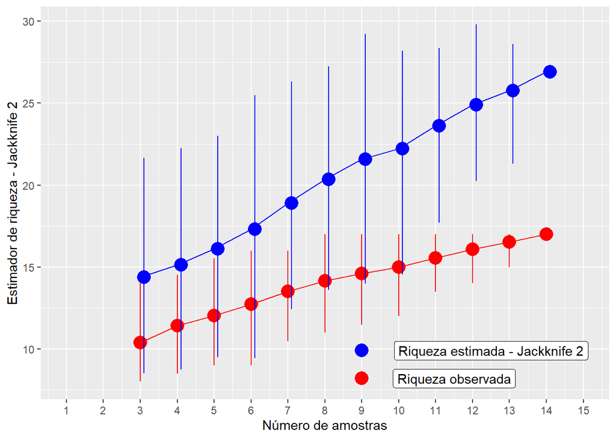

```r
library(ggplot2)
# preparando os dados para fazer o gráfico
resultados_jack2 <- summary(est_jack2, display = c("S", "jack2"))
res_jack2 <- cbind(resultados_jack2$jack2[,1:4], resultados_jack2$S[,2:4])
res_jack2 <- as.data.frame(res_jack2)
colnames(res_jack2) <- c("Amostras", "JACK2", "JACK2_inferior", "JACK2_superior", "Riqueza",
                        "R_inferior", "R_superior")

# comando para o gráfico
ggplot(res_jack2, aes(y = Riqueza, x = Amostras)) +
  geom_point(aes(y = JACK2, x = Amostras + 0.1), size = 5, color = "blue", alpha = 1) +
  geom_point(aes(y = Riqueza, x = Amostras), size = 5, color = "red", alpha = 1) +
  geom_line (aes(y = JACK2, x = Amostras), color = "blue") +
  geom_line (aes(y = Riqueza, x = Amostras), color = "red") +
  geom_linerange(aes(ymin = JACK2_inferior, ymax = JACK2_superior, x = Amostras + 0.1),
 color = "blue") +
  geom_linerange(aes(ymin = R_inferior, ymax = R_superior, x = Amostras), color = "red") +
  ylab ("Estimador de riqueza - Jackknife 2") +
  xlab ("Número de amostras") +
  scale_x_continuous(limits = c(1,15), breaks=seq(1,15,1)) +
  geom_point(y= 9.9, x = 9, size = 5, color = "blue", alpha = 1) +
  geom_point(y= 8.2, x = 9, size = 5, color = "red", alpha = 1) +
  geom_label( y = 9.9, x = 12.5, label = "Riqueza estimada - Jackknife 2") +
  geom_label( y = 8.2, x = 11.5, label = "Riqueza observada")
```

#### Interpretação dos resultados

Com base no número de espécies raras, o estimador Jackknife 2 calculou a possibilidade de encontrarmos mais dez espécies caso o esforço amostral fosse maior e não mostrou tendência estabilização da curva em uma assíntota.

### BOOTSTRAP (Smith and van Belle 1984):

Este método difere dos demais por utilizar dados de todas as espécies coletadas para estimar a riqueza total, não se restringindo às espécies raras. Ele requer somente dados de incidência. A estimativa pelo bootstrap é calculada somando-se a riqueza observada à soma do inverso da proporção de amostras em que cada espécie ocorre.

> $$S_{boot} = S_{obs} + \sum_{k=1}^{S_{obs}}(1-P_k)^m$$

onde:

- S<sub>obs</sub> = o número de espécies na comunidade,
- *m* = número de amostragens,
- P<sub>k</sub> = proporção do número de amostras em que cada espécie foi registrada.

#### Exemplo prático - Bootstrap

##### Explicação dos dados

Usaremos os mesmos dados de 17 espécies de anuros amostradas em 14 dias de coletas de campo em um habitat reprodutivo localizado na região noroeste do estado de São Paulo, Brasil.

**Pergunta:**

> Quantas espécies a mais poderiam ser amostradas caso aumentasse o esforço amostral?

**Predições**

> - O número de espécies estimadas é similar ao número de espécies observada;
> - O número de espécies estimadas é maior do que o número de espécies observada.

**Variáveis**

- Variáveis preditoras
  - matriz ou vetor com as abundâncias das espécies de anuros registradas em uma habitat reprodutivo

**Checklist**

- Verificar se a sua matriz está com as espécies nas colunas e as amostragens nas linhas

### Análise

Calculo do estimador de riqueza - Bootstrap

```r
library(vegan)
dados_coleta <- read.csv("anuros_poca.csv", header = T, row.names = 1, sep = ";")
est_boot <- poolaccum(dados_coleta, permutations = 100)
summary(est_boot, display = "boot")
```

```
## $boot
##        N Bootstrap      2.5%    97.5%   Std.Dev
##  [1,]  3  12.41963  8.407407 17.51852 2.3237086
##  [2,]  4  13.28324  8.944824 17.45410 2.3560418
##  [3,]  5  14.27168  9.884528 18.31494 2.0365108
##  [4,]  6  14.95227 10.617194 18.62030 2.0965195
##  [5,]  7  15.59522 11.179958 19.45310 2.0439907
##  [6,]  8  16.18473 12.381818 19.79260 1.9360576
##  [7,]  9  16.64092 12.278923 19.58676 1.9679968
##  [8,] 10  17.15916 13.482384 19.58360 1.7642521
##  [9,] 11  17.92332 13.928612 19.59637 1.5852959
## [10,] 12  18.41159 15.374450 19.58719 1.2840560
## [11,] 13  18.83065 16.570376 19.47661 0.9007351
## [12,] 14  19.27832 19.278321 19.27832 0.0000000
##
## attr(,"class")
## [1] "summary.poolaccum"
```

Visualizar os resultados com intervalo de confiança de 95%

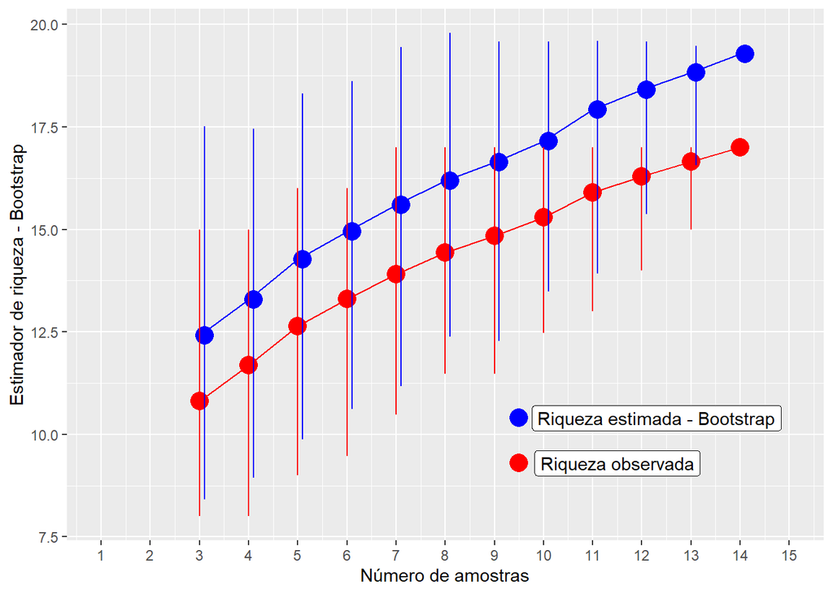

```r
library(ggplot2)
# preparando os dados para fazer o gráfico
resultados_boot <- summary(est_boot, display = c("S", "boot"))
res_boot <- cbind(resultados_boot$boot[,1:4], resultados_boot$S[,2:4])
res_boot <- as.data.frame(res_boot)
colnames(res_boot) <- c("Amostras", "BOOT", "BOOT_inferior", "BOOT_superior", "Riqueza",
                        "R_inferior", "R_superior")

# comando para o gráfico
ggplot(res_boot, aes(y = Riqueza, x = Amostras)) +
  geom_point(aes(y = BOOT, x = Amostras + 0.1), size = 5, color = "blue", alpha = 1) +
  geom_point(aes(y = Riqueza, x = Amostras), size = 5, color = "red", alpha = 1) +
  geom_line (aes(y = BOOT, x = Amostras), color = "blue") +
  geom_line (aes(y = Riqueza, x = Amostras), color = "red") +
  geom_linerange(aes(ymin = BOOT_inferior, ymax = BOOT_superior, x = Amostras + 0.1),
 color = "blue") +
  geom_linerange(aes(ymin = R_inferior, ymax = R_superior, x = Amostras), color = "red") +
  ylab ("Estimador de riqueza - Bootstrap") +
  xlab ("Número de amostras") +
  scale_x_continuous(limits = c(1,15), breaks=seq(1,15,1)) +
  geom_point(y= 10.4, x = 9.5, size = 5, color = "blue", alpha = 1) +
  geom_point(y= 9.3, x = 9.5, size = 5, color = "red", alpha = 1) +
  geom_label( y = 10.4, x = 12.3, label = "Riqueza estimada - Bootstrap") +
  geom_label( y = 9.3, x = 11.5, label = "Riqueza observada")
```

#### Interpretação dos resultados

Com base na frequencia de ocorrência das espécies, o estimador bootstrap calculou a possibilidade de encontrarmos mais duas espécies caso o esforço amostral fosse maior e não mostrou tendência de estabilização da curva em uma assíntota.

### Interpolação e Extrapolação baseadas em rarefação usando amostragens de incidência ou abundância (Chao and Jost 2012; Colwell et al. 2012):

Este método utiliza teoria de amostragem (e.g. modelos multinomial, Poisson e Bernoulli) para conectar rarefação (interpolação) e predição (extrapolação) com base no tamanho da amostra. Contudo, é importante enfatizar que a extrapolação torna-se altamente incerta quando extendida para o dobro do tamanho da amostragem. Este método utiliza uma abordagem com bootstrap para calcular o intervalo de confiança de 95%.

#### Exemplo prático 1

##### Explicação dos dados

Usaremos os mesmos dados de 17 espécies de anuros amostradas em 14 dias de coletas de campo em um habitat reprodutivo localizado na região noroeste do estado de São Paulo, Brasil.

**Pergunta:**

> Quantas espécies a mais poderiam ser amostradas caso aumentasse o esforço amostral?

**Predições**

> - O número de espécies estimadas é similar ao número de espécies observada;
> - O número de espécies estimadas é maior do que o número de espécies observada.

**Variáveis**

- Variáveis preditoras
  - matriz ou vetor com as abundâncias das espécies de anuros registradas em uma habitat reprodutivo

**Checklist**

- Verificar se a sua matriz está com as espécies nas colunas e as amostragens nas linhas.

### Análise

Calculo da extrapolação da riqueza com base no número de indivíduos

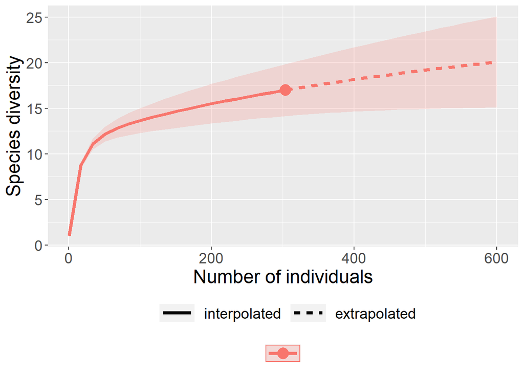

```r
library(iNEXT)
dados_coleta <- read.csv("anuros_poca.csv", header = T, row.names = 1, sep = ";")

# preparando os dados para análises considerando a abundância
dados_inext_abu <- colSums(dados_coleta)

resultados_abundancia <- iNEXT(dados_inext_abu, q = 0, datatype = "abundance",
            endpoint = 600)

# Visualizar os dados no gráfico
ggiNEXT(resultados_abundancia, type = 1)
```

#### Interpretação dos resultados

Veja que o ponto no final da linha contínua representa as 17 espécies de anuros (eixo Y) observadas entre os 304 individuos (eixo X). A extrapolação máxima (600 indivíduos no nosso exemplo), estima um aumento de até oito espécies (intervalo de confiança) caso amostrássemos mais 300 indivíduos.

Calculo da extrapolação da riqueza com base no número de amostras

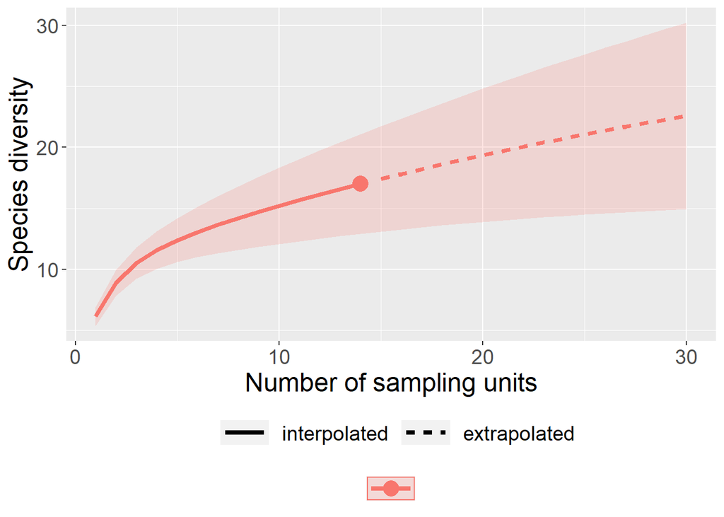

```r
library(iNEXT)
dados_coleta <- read.csv("anuros_poca.csv", header = T, row.names = 1, sep = ";")

# preparando os dados para análises considerando a incidência
dados_inext <- as.incfreq(t(dados_coleta)) # preciso transpor o dataframe

resultados_incidencia <- iNEXT(dados_inext, q = 0, datatype = "incidence_freq",
            endpoint = 30)

# Visualizar os dados no gráfico
ggiNEXT(resultados_incidencia, type = 1)
```

#### Interpretação dos resultados

Veja que o ponto no final da linha contínua representa as 17 espécies de anuros (eixo Y) observadas nos 14 dias de coleta (eixo X - amostras). A extrapolação máxima (30 dias de coleta no nosso exemplo), estima um aumento de até 13 espécies (intervalo de confiança) caso amostrássemos mais 16 dias.

#### Exemplo prático 2

##### Explicação dos dados

Neste exemplo iremos refazer o exemplo do Capítulo 6 que usa generalized least squares (GLS) para testar a relação da riqueza de ácaros com a quantidade de água no substrato. Contudo, ao invés de considerar a riqueza de espécies de ácaros observada como variável resposta, iremos utilizar a riqueza extrapolada. Os dados que usaremos estão disponíveis no pacote *vegan* e representa a composição de espécies de ácaros amostradas em 70 comunidades.

**Pergunta:**

> A riqueza extrapolada de espécies de ácaros é maior em comunidades localizadas em áreas com substratos secos?

**Predições**

> O número de espécies extrapolada será maior em substratos secos uma vez que as limitações fisiológicas impostas pela umidade limitam a ocorrência de várias espécies de ácaros.

**Variáveis**

- Variáveis preditoras
  - matriz ou dataframe com as abundâncias das espécies de ácaros registradas em 70 comunidades.

**Checklist**

- Verificar se a sua matriz ou dataframe estão com as espécies nas linhas e as comunidades nas colunas.

### Análise

Vamos iniciar carregando os dados do pacote *vegan* (Oksanen et al. 2019), e depois, calcular a riqueza extrapolada com base na comunidade com maior abundância.

```r
library(vegan)
library(iNEXT)

# Carregando os dados de composição disponível no pacote vegan
data("mite")

# Os dados estão com as comunidades nas colunas e as espécies nas linhas. Para as análises teremos que transpor a planilha.
composicao_acaros <- t(mite)

# A comunidade com maior abundância tem 781 indivíduos.
max(colSums(composicao_acaros))
```

```
## [1] 781
```

```r
# Calcular a riqueza extrapolada de espécies para todas as comunidades considerando a maior abundância.
resultados_extrapolacao <- iNEXT(composicao_acaros, q = 0,
                              datatype = "abundance",
                              endpoint = 781)

# Criando um loop para extrair a riqueza extrapolada para as 70 comunidades
resultados_comunidades_ext <- data.frame()
riqueza_extrapolada <- c()
for (i in 1:70){
resultados_comunidades_ext <- data.frame(resultados_extrapolacao$iNextEst[i])
riqueza_extrapolada[i] <- resultados_comunidades_ext[40,4]
}
```

Agora, seguindo os passos descritos no Capítulo 6, vamos identificar o melhor modelo que representa a estrutura espacial dos dados extrapolados.

```r
library(nlme)
library(dplyr)
library(piecewiseSEM)

# dados coordenadas geográficas
data("mite.xy")
coord <- mite.xy
colnames(coord) <- c("long", "lat")

# dados ambientais
data("mite.env")
agua <- mite.env[,2]

# Data frame final
dados_combinado_ext <- data.frame(riqueza_extrapolada, agua, coord)

# Modelo gls sem estrutura espacial

no_spat_gls <- gls(riqueza_extrapolada ~ agua,
                   data = dados_combinado_ext,
                   method = "REML")

# Covariância esférica
espher_model <- gls(riqueza_extrapolada ~ agua,
                    data = dados_combinado_ext,
                    corSpher(form=~lat+long, nugget = TRUE))

# Covariância exponencial (corExp(form=~lat+long))
expon_model <- gls(riqueza_extrapolada ~ agua,
                   data = dados_combinado_ext,
                   corExp(form=~lat+long, nugget = TRUE))

# Covariância Gaussiana (corGaus(form=~lat+long))
gauss_model <- gls(riqueza_extrapolada ~ agua,
                   data = dados_combinado_ext,
                   corGaus(form=~lat+long, nugget = TRUE))

# Covariância linear (corLin(form=~lat+long)
cor_linear_model <- gls(riqueza_extrapolada ~ agua,
                        data = dados_combinado_ext,
                        corLin(form=~lat+long, nugget = TRUE))

# Covariância razão quadrática (corRatio(form=~lat+long))
ratio_model <- gls(riqueza_extrapolada ~ agua,
                   data = dados_combinado_ext,
                   corRatio(form=~lat+long, nugget = TRUE))
```

Vamos usar o AIC para selecionar o modelo mais “provável” explicando a distribuição da riqueza extrapolada das espécies de ácaros.

```r
# Seleção dos modelos
aic_fit_ext <- AIC(no_spat_gls, espher_model,
                   cor_linear_model, expon_model,
                   gauss_model, ratio_model)

aic_fit_ext %>% arrange(AIC)
```

```
##                  df      AIC
## ratio_model       5 467.9349
## no_spat_gls       3 469.3103
## cor_linear_model  5 473.2373
## espher_model      5 473.2815
## gauss_model       5 473.3086
## expon_model       5 473.3103
```

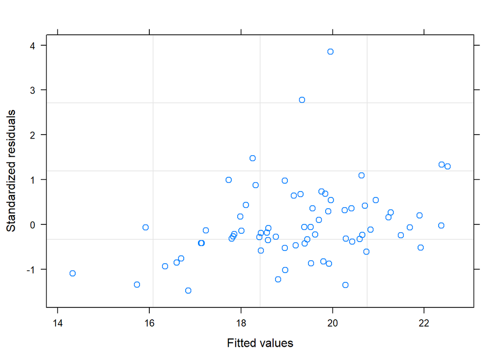

```r
# Visualizando os resíduos do modelo selecionado
plot(ratio_model)
```

```r
# Visualizando os resultados e calculando pseudo-R-squared
summary(ratio_model)$tTable
```

```
##                   Value   Std.Error   t-value      p-value
## (Intercept) 24.09577588 4.816461582  5.002796 4.227862e-06
## agua        -0.01181425 0.006977381 -1.693221 9.499017e-02
```

```r
rsquared(ratio_model)
```

```
##              Response   family     link method  R.squared
## 1 riqueza_extrapolada gaussian identity   none 0.05977552
```

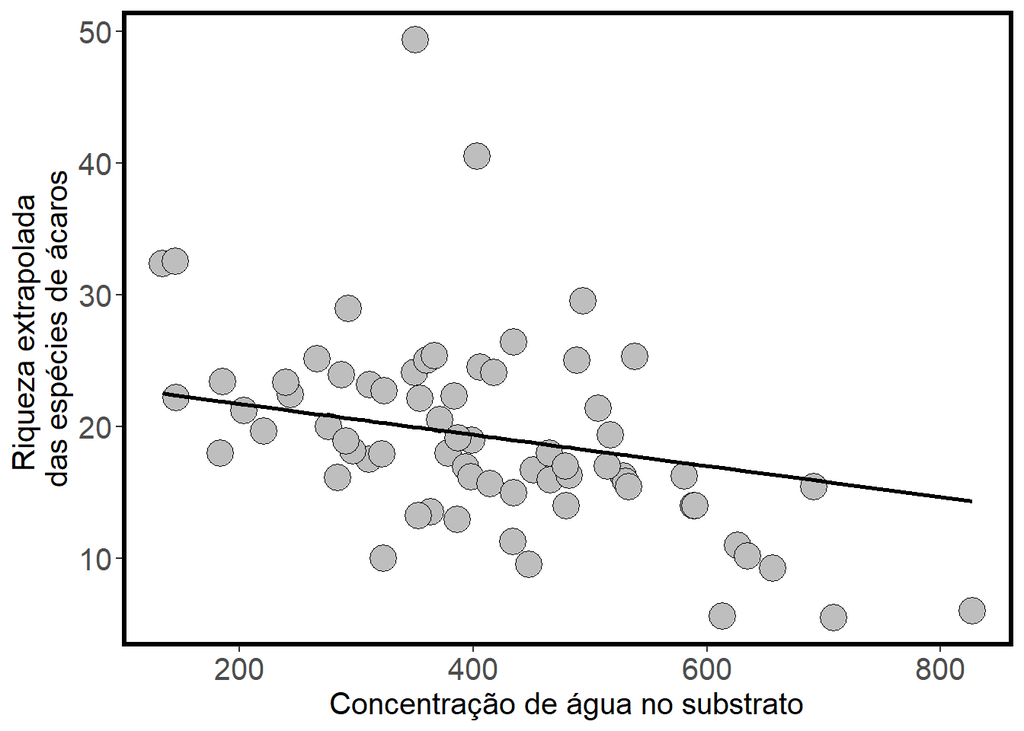

```r
# Plotando os resultados no gráfico.
library(ggplot2)
predito_ext <-  predict(ratio_model)

ggplot(data = dados_combinado_ext, aes(x= agua, y= riqueza_extrapolada)) +
  labs(x = "Concentração de água no substrato",
       y = "Riqueza extrapolada \ndas espécies de ácaros", size = 15) +
  geom_point(size = 6, shape = 21, fill = "gray") +
  theme_bw() +
  theme(axis.title.y = element_text(size = 15),
        axis.title.x = element_text(size = 15)) +
  theme(axis.text.y = element_text(size = 15),
        axis.text.x = element_text(size = 15)) +
  theme(panel.grid.major = element_blank(),
        panel.grid.minor = element_blank(),
        panel.border = element_rect(colour = "black", fill=NA, size = 2)) +
  geom_line(aes(y = predito_ext), size = 1)
```

### Para se aprofundar

- Recomendamos aos interessados que olhem a página do [EstimateS software](http://viceroy.eeb.uconn.edu/estimates) e baixem o manual do usuário que contém informações detalhadas sobre os índices de rarefação e estimadores de riqueza.Este site foi criado e é mantido pelo Dr. Robert K. Colwell, um dos maiores especialistas do mundo em estimativas da biodiversidade
- Recomendamos também o livro *Biological Diversity Frontiers in Measurement and Assessment* (Magurran and McGill 2011).

### Referência

Burnham, K. P., and W. S. Overton. 1978. “Estimation of the Size of a Closed Population When Capture Probabilities Vary Among Animals.” *Biometrika* 65 (3): 625–33. https://doi.org/10.1093/biomet/65.3.625.

———. 1979. “Robust Estimation of Population Size When Capture Probabilities Vary Among Animals.” *Ecology* 60 (5): 927–36. https://doi.org/10.2307/1936861.

Chao, Anne. 1984. “Nonparametric Estimation of the Number of Classes in a Population.” *Scandinavian Journal of Statistics* 11 (4): 265–70. http://www.jstor.org/stable/4615964.

———. 1987. “Estimating the Population Size for Capture-Recapture Data with Unequal Catchability.” *Biometrics* 43 (4): 783. https://doi.org/10.2307/2531532.

Chao, Anne, Wen-Han Hwang, Y-C Chen, and C-Y Kuo. 2000. “Estimating the Number of Shared Species in Two Communities.” *Statistica Sinica* 10 (1): 227–46. http://www.jstor.org/stable/24306714.

Chao, Anne, and Lou Jost. 2012. “Coverage-Based Rarefaction and Extrapolation: Standardizing Samples by Completeness Rather Than Size.” *Ecology* 93 (12): 2533–47. https://doi.org/10.1890/11-1952.1.

Chao, Anne, and Shen-Ming Lee. 1992. “Estimating the Number of Classes via Sample Coverage.” *Journal of the American Statistical Association* 87 (417): 210–17. https://doi.org/10.1080/01621459.1992.10475194.

Chazdon, Ronbin L., Robert K. Colwell, Julie S. Denslow, and Manuel R. Guariguata. 1998. “Statistical Methods for Estimating Species Richness of Woody Regeneration in Primary and Secondary Rain Forest of Northeastern Costa Rica.” In *Forest Biodiversity, Research. Monitoring and Modeling: Conceptual Background and Old World Case Studies*, edited by F. Dallmeier and J. A. Comiskey, 285–309. Paris; New York: UNESCO; The Parthenon Publishing Group.

Colwell, R. K., A. Chao, N. J. Gotelli, S.-Y. Lin, C. X. Mao, R. L. Chazdon, and J. T. Longino. 2012. “Models and Estimators Linking Individual-Based and Sample-Based Rarefaction, Extrapolation and Comparison of Assemblages.” *Journal of Plant Ecology* 5 (1): 3–21. https://doi.org/10.1093/jpe/rtr044.

Colwell, R. K., and J. A. Coddington. 1994. “Estimating Terrestrial Biodiversity Through Extrapolation.” *Philosophical Transactions of the Royal Society of London. Series B: Biological Sciences* 345 (1311): 101–18. https://doi.org/10.1098/rstb.1994.0091.

Gotelli, Nicholas J., and Anne Chao. 2013. “Measuring and Estimating Species Richness, Species Diversity, and Biotic Similarity from Sampling Data.” In, 195–211. Elsevier. https://doi.org/10.1016/b978-0-12-384719-5.00424-x.

Hortal, Joaquin, Paulo A. V. Borges, and Clara Gaspar. 2006. “Evaluating the Performance of Species Richness Estimators: Sensitivity to Sample Grain Size.” *Journal of Animal Ecology* 75 (1): 274–87. https://doi.org/10.1111/j.1365-2656.2006.01048.x.

Magurran, Anne E., and Brian J. McGill. 2011. *Biological Diversity: Frontiers in Measurement and Assessment*. Oxford: Oxford University Press.

Oksanen, Jari, F. Guillaume Blanchet, Michael Friendly, Roeland Kindt, Pierre Legendre, Dan McGlinn, Peter R. Minchin, et al. 2019. *Vegan: Community Ecology Package*. https://CRAN.R-project.org/package=vegan.

Palmer, Michael W. 1990. “The Estimation of Species Richness by Extrapolation.” *Ecology* 71 (3): 1195–8. https://doi.org/10.2307/1937387.

———. 1991. “Estimating Species Richness: The Second-Order Jackknife Reconsidered.” *Ecology* 72 (4): 1512–3. https://doi.org/10.2307/1941127.

Smith, Eric P., and Gerald van Belle. 1984. “Nonparametric Estimation of Species Richness.” *Biometrics* 40 (1): 119. https://doi.org/10.2307/2530750.

Walther, Bruno A., and Joslin L. Moore. 2005. “The Concepts of Bias, Precision and Accuracy, and Their Use in Testing the Performance of Species Richness Estimators, with a Literature Review of Estimator Performance.” *Ecography* 28 (6): 815–29. https://doi.org/10.1111/j.2005.0906-7590.04112.x.